# Python for Genomic Data Science

## 2.3 First Steps Towards Programming Part 2

### 2.3.1 Variables

Variables are the *storage containers* for our data, no matter the type or structure. The **=** sign is used to assign a value to a variable.

```python
codon = "atg"

dna_sequence = "atgctgctgatgtgctga"
```

As shown, if if is not order to Python, then it will not return the values we assigned to our variables, meaning they exist, but are not shown. In the same fashion, typing an unexisting/undefined name of a variable will just send an error. We can change the values to the same variable, which can overwrite the value, or even copy the value from a variable into another.

```r
a = 4
a
```

```
## [1] 4
```

```r
b = a
b
```

```
## [1] 4
```

```r
b = b+3
b
```

```
## [1] 7
```

Generally speaking, the name of the variables must have meaningful names, so it can be understood by others and yourself in later times. Python is case-sensitive, so we must pay attention when defining our variables. We have to account that some characters cannot be used in the variables’ names, such as special characters and numbers as the first character of the variable’s name.

We can also try to find specific positions or locations of a string without having to print the whole string. Indexing refers to selecting the character at position *x* that has been selected. Slicing refers to making a substring form the original between the selected *x* and *y* positions. It is important to note that the string in Python, and some other languages, start at number 0 rather than 1.

```python
dna = "ttagctgactgatgcgctagctagctgactgatcg"

dna[0]
```

```
## 't'
```

```python
dna[0:3]
```

```
## 'tta'
```

```python
dna[:3]
```

```
## 'tta'
```

```python
dna[2:]
```

```
## 'agctgactgatgcgctagctagctgactgatcg'
```

In the previous slicing example, we want to select the first 3 characters from our string. We may think it would consider the first 4 characters since we begin in 0, but the 3 at the end of the slice means it will take everything **before** the specified end of the slice.

We can also select negative numbers, which start counting from the right, meaning the end of the string.

```python
dna = "ttagctgactgatgcgctagctagctgactgatcg"

# the last character
dna[-1]
```

```
## 'g'
```

When we wish to know the length of our strings, we can use the function `len()` to directly return the length.

```python
dna = "ttagctgactgatgcgctagctagctgactgatcg"

len(dna)
```

```
## 35
```

There are many other functions that can be used for a variety of reasons and scenarios, such as `type()` and `print()`. If any questions arise and we need more information about the function, we can simply type `help(name_of_function)` and it will give us more information.

Our variables are objects too, so we can make more with them. Specific functions and actions can be performed onto our variables, these are called *methods*. For example, we can use the function `name_of_variable.count()` to count how many times does a character repeat itself in the string.

```python
dna = "ttagctgactgatgcgctagctagctgactgatcg"

dna.count("c")
```

```
## 8
```

```python
dna.count("gc")
```

```
## 5
```

Other examples include the change of lower-case to upper-case characters and vice-versa. Even finding substring can be done with the method `.find()`, this will yield the position in which the specified substring starts in the original, but only the first one; we can change where it starts looking with parameters, even starting from the end.

```python
dna = "ttagctgactgatgcgctagctagctgactgatcg"

dna.upper()
```

```
## 'TTAGCTGACTGATGCGCTAGCTAGCTGACTGATCG'
```

```python
dna.find("atgc")
```

```
## 11
```

```python
dna.find("atcg",11)
```

```
## 31
```

```python
dna.rfind("tta")
```

```
## 0
```

Other functions do not modify the string, but analyse what it contains and gives us more information. To exemplify, the functions `.islower()` and `.isupper()` both will tell us if our string complies with the rules, in this case, if the string is in upper or lower-case letters.

```python
dna = "ttagctgactgatgcgctagctagctgactgatcg"

dna.islower()
```

```
## True
```

```python
dna.isupper()
```

```
## False
```

Another useful string method is replacing certain characters for others.

```python
dna = "ttagctgactgatgcgctagctagctgactgatcg"

dna.replace("a","A")
```

```
## 'ttAgctgActgAtgcgctAgctAgctgActgAtcg'
```

## 2.4 First Steps Toward Programming Part 3

We’ll make the first program using Python in this lecture. Starting from the creation of the pseudo code that will later be translated into actual code for us to determine the GC’s concentration in a string. First of all, we’ll declare the “dna” variable which will contain the sequence in question.

```python
# read DNA sequence from user
dna = "atcgtgatcgatgctagctagtagctagctgactagtcgatcgatcgtagc"
```

```python
# count the number of C's in the DNA sequence
no_c = dna.count("c")
```

```python
# count the number of G's in the DNA sequence
no_g = dna.count("g")
```

```python
# determine the length of the DNA sequence
dna_len = len(dna)
```

```python
# compute the GC percentage
gc_percent = (no_c+no_g)/dna_len*100
```

```python
# print the value
print(gc_percent)
```

```
## 49.01960784313725
```

For a cleaner view, and less decimals and more information at the time of viewing our output, the `print()` function can be of use. Here we have formatting elements of a string, the formatting characters are the **%** and the **f** in this case. The syntaxis is that the symbol **%** refers that a format will follow, then de **5** refers to the total number of digits, then the **.** and then the **3**; in this case it tells Python we only want 3 digits following the dot; finally, the **f** or any letter refers to the type of the value to format.

```python
print("The DNA sequence's GC content is %5.3f %%" % gc_percent)
```

```
## The DNA sequence's GC content is 49.020 %
```

For us to later use the same code again, instead of writing all over again, we can execute the code from a file. We write the code in the file and use the Python interpreter for it to execute the code as many times as we want. The files should have the **.py** extension for better location and identification of the Python files in the project. For it to run directly as a bash script, we can add the special header for our file to be executable.

```
#!/directory_where_python_is/python

# read DNA sequence from user
dna = "atcgtgatcgatgctagctagtagctagctgactagtcgatcgatcgtagc"

# count the number of C's in the DNA sequence
no_c = dna.count("c")

# count the number of G's in the DNA sequence
no_g = dna.count("g")

# determine the length of the DNA sequence
dna_len = len(dna)

# compute the GC percentage
gc_percent = (no_c+no_g)/dna_len*100

# print the value
print(gc_percent)
```

We can run the file directly from the interpreter by specifying the location and the name of the file within the prompt.

```
directory_location_whatever python file_name.py
```

Most probably, the file will have a problem since UNIX won’t recognize it as an executable file. To fix this problem, we use the `chmod` command and the name of our file for it to be considered and executable program. There are also ways of executing the file directly from the Python interpreter. All this looks as follows.

```
chmod a+x file_name.py

directory_location_whatever ./file_name.py
```

On another note, comments are fundamental to understand what we see and what we tried to achieve in the code. Meaningful names and comments are invaluable for a cleaner and better code. An example looks like this.

```
#!/directory_where_python_is/python

# multiple lines of comments can be set with triple quotes
"""
This is my  first Python program.
It computes the GC content of a DNA sequence.
"""

# short comments can be done with the #

# read DNA sequence from user
dna = "atcgtgatcgatgctagctagtagctagctgactagtcgatcgatcgtagc"

# count the number of C's in the DNA sequence
no_c = dna.count("c")

# count the number of G's in the DNA sequence
no_g = dna.count("g")

# determine the length of the DNA sequence
dna_len = len(dna)

# compute the GC percentage
gc_percent = (no_c+no_g)/dna_len*100

# print the value
print(gc_percent)
```

## 2.5 First Steps Toward Programming Part 4

The inputs for our programs may come from different sources. Up until now, the input has been manually given and done by ourselves, but it can be given by a series of sources such as other files or even the users. We can see an example of the latter as follows.

```python
# it will wait for the user to write something and will be assigned to the object "dna"
# dna = input("Enter a DNA sequence, please:")
dna = "tgactgactgac"
print(dna)
```

```
## tgactgactgac
```

It is important to know that the input in this case will always give a string type object, we can later convert it as in the example below; but we must always remember it is initially a string.

```python
#give a number
# my_number = input("Please enter a number:")
my_number = "12"
```

```python
# check for data type
type(my_number)
```

```
## <class 'str'>
```

```python
# make it into an actual number
actual_number = int(my_number)
```

```python
# Check for data type
type(actual_number)
```

```
## <class 'int'>
```

We have other conversion functions into specific data types. They will be more useful along the way.

| Function | Description |
| --- | --- |
| int(x [,base]) | Converts x to an integer |
| float(x) | Converts x to a floating-point (real) number |
| complex(real [,imag]) | Creates a complex number |
| str(x) | Converts x to a string |
| chr(x) | Converts an integer to a character |

# 3 Module 2

## 3.1 Data Structures Part 1

### 3.1.1 Lists

It is an ordered set of values. We can have a list with different data types, not necessarily even numeric. We can make a list into a variable as follows.

```python
# we define it with brackets
gene_exp = ["gene", 5.18e-08, 0.00]

# access individual elements or intervals
gene_exp[:2]
```

```
## ['gene', 5.18e-08]
```

We can access to different elements as any other variable, and starts with **0** rather than 1 when we start listing. Antoher interesting thing we can do with the list data types, is the modification of specific data within a previously created list.

```python
# the original list
gene_exp = ["gene", 5.18e-08, 0.00]

# replace the element and check it is there
gene_exp[0] = "lif"
gene_exp
```

```
## ['lif', 5.18e-08, 0.0]
```

We must be careful not to convert a string into a list, such as to change nucleotides in a sequence. This will return an error. Strings are **immutable**, unlike lists.

We can slice the lists, and return just the list with the assigned elements from the original.

```python
# the original list
gene_exp = ["gene", 5.18e-08, 0.00, 0.00023042347, "twelve"]
```

```python
# slicing
gene_exp[-3:] #this will return all the elements after the third to last element in the list
```

```
## [0.0, 0.00023042347, 'twelve']
```

We can also replace multiple elements of the list with just one new element and from the range we want, meaning specific locations within the list. It can be seen as follows.

```python
gene_exp
```

```
## ['gene', 5.18e-08, 0.0, 0.00023042347, 'twelve']
```

```python
gene_exp[1:3] = [6.09e-02]
gene_exp
```

```
## ['gene', 0.0609, 0.00023042347, 'twelve']
```

To concatenate lists, we use the **+** sign and create a new list that will have to be assigned to another variable. We can even clear a list by specifying all the positions and assigning nothing, just leave the brackets empty.

```python
# Concatenate
list_1 = [234,43243, 0.000023404, "jknwfiujn"]

list_2 = gene_exp

list_1+list_2
```

```
## [234, 43243, 2.3404e-05, 'jknwfiujn', 'gene', 0.0609, 0.00023042347, 'twelve']
```

```python
# empty a list
list_3 = list_1
list_3
```

```
## [234, 43243, 2.3404e-05, 'jknwfiujn']
```

```python
list_3[:] = []
list_3
```

```
## []
```

To delete specific elements in the list, the function `del` can be used to do this. **This will take effect immeadiately. overwriting the original list without having to re-assign**

```python
list_2
```

```
## ['gene', 0.0609, 0.00023042347, 'twelve']
```

```python
del list_2[1]
list_2
```

```
## ['gene', 0.00023042347, 'twelve']
```

To work with lists as objects, we have several methods which yield different results and can be applied differently. Certain methods such as `.extend` can immediately add new elements. Method `.count` helps us count the number of times an element appears in a list. Other useful method is `.reverse`, which, as it is obviously implied, reverses the entire list.

```python
gene_exp
```

```
## ['gene', 0.00023042347, 'twelve']
```

```python
gene_exp.extend([23123, "hello"])
gene_exp
```

```
## ['gene', 0.00023042347, 'twelve', 23123, 'hello']
```

```python
gene_exp.count("lif")
```

```
## 0
```

```python
gene_exp.count("gene")
```

```
## 1
```

```python
gene_exp
```

```
## ['gene', 0.00023042347, 'twelve', 23123, 'hello']
```

```python
gene_exp.reverse()
```

The specific methods called `.append` and `pop` are of particular importance when using lists as stacks; meaning where the last element added is the first element retrieved (the first dish under the pile will be last cleaned, while the last will be the first).

An important difference between the `.append` and `.extend` methods, is that the first one will only add one element at a time, so even if you give a list, it will make it a single element inserted at the end of the list; the latter uses lists as arguments and adds many elements.

```python
stack = ["a","b","c","d"]
```

```python
stack.append("e")
```

The method `.pop` can be used to retrieve the last element from a list, we pop it out. This method is also very powerful, as it will eliminate the last element immediately, just as the previous methods added elements in the same fashion.

```python
stack
```

```
## ['a', 'b', 'c', 'd', 'e']
```

```python
elem = stack.pop()
elem
```

```
## 'e'
```

```python
stack
```

```
## ['a', 'b', 'c', 'd']
```

To sort the elements of a list, we can use different functions, such as `sorted()` or even using the method list, which will directly change the order of the elements in the list. It doesn’t have to be numbers, the letters will give priority to capital letters and alphabetical order.

```python
list_t = [234,235,56,1,23,5]

sorted(list_t)
```

```
## [1, 5, 23, 56, 234, 235]
```

```python
list_t.sort()
```

## 3.2 Data Structures Part 2

### 3.2.1 Tuples

A tuple consists of a number of values separated by commas, and is another standard sequence data type, like strings and lists. Their elements cannot be changed, therefore, they are immutable objects. The object can be created directly with or without brackets at the start and the end. They can be manipulated as lists, which can be sliced or indexed and are usually composed of heterogeneous sequence of elements.

```python
t = 1,2,3
t
```

```
## (1, 2, 3)
```

### 3.2.2 Sets

This are unordered collections with no duplicate elements. They support mathematical operations like unions, intersections and differences. They can be lists with no replicate elements. These are created with the **{}** brackets, and can be used to check for similarities and differences alike.

```python
br_1 = {"gene","DNA","repair","like","math","wisdom"}

br_2 = {"gene","DNA","destroy","dislike","english","wisdom","wisdom"}
```

```python
# union
br_1 | br_2
```

```
## {'math', 'wisdom', 'DNA', 'like', 'english', 'repair', 'destroy', 'dislike', 'gene'}
```

```python
# intersection
br_1 & br_2
```

```
## {'wisdom', 'DNA', 'gene'}
```

```python
# difference
br_1 - br_2
```

```
## {'repair', 'like', 'math'}
```

### 3.2.3 Dictionaries

They can store things we want to look up later. It is an unordered set of key and value pairs, with the requirement that the keys are unique (within the dictionary). We associate values with specific keys for later retrieval. The keys can me any immutable data type and the values can be of any data type. Each key is defined, then we use the **:** to assign the value to the key; each key and its value is separated by a **,**.

```python
TF_motif = {"SP1":"gggcgg", "C/EBP":"attgcgcaat", "ATF":"tgacgtca", "c-Myc":"cacgtg", "Oct-1":"atgcaaat"}
```

To access a dictionary value within, we use a key within square brackets to obtain the value. Any key that is not annotated will yield an error message. The special word `in` can be used to know if the key is in the dictionary.

```python
TF_motif["ATF"]
```

```
## 'tgacgtca'
```

We can add new keys and values by simply creating it the same way we search for the value in the dictionary, with the exception we have to give the value of the new key.

```python
TF_motif
```

```
## {'SP1': 'gggcgg', 'C/EBP': 'attgcgcaat', 'ATF': 'tgacgtca', 'c-Myc': 'cacgtg', 'Oct-1': 'atgcaaat'}
```

```python
TF_motif["AP-1"] = "tgagtca"

TF_motif
```

```
## {'SP1': 'gggcgg', 'C/EBP': 'attgcgcaat', 'ATF': 'tgacgtca', 'c-Myc': 'cacgtg', 'Oct-1': 'atgcaaat', 'AP-1': 'tgagtca'}
```

To modify an existing key’s value, we do the exact same process as adding a new key and value with the difference that in the squared brackets it should be written the name of the key value to update.

```python
TF_motif
```

```
## {'SP1': 'gggcgg', 'C/EBP': 'attgcgcaat', 'ATF': 'tgacgtca', 'c-Myc': 'cacgtg', 'Oct-1': 'atgcaaat', 'AP-1': 'tgagtca'}
```

```python
TF_motif["AP-1"] = "tga(g/c)tca"

TF_motif
```

```
## {'SP1': 'gggcgg', 'C/EBP': 'attgcgcaat', 'ATF': 'tgacgtca', 'c-Myc': 'cacgtg', 'Oct-1': 'atgcaaat', 'AP-1': 'tga(g/c)tca'}
```

To delete an existing key, we use the function `del` which will act immediately.

```python
TF_motif
```

```
## {'SP1': 'gggcgg', 'C/EBP': 'attgcgcaat', 'ATF': 'tgacgtca', 'c-Myc': 'cacgtg', 'Oct-1': 'atgcaaat', 'AP-1': 'tga(g/c)tca'}
```

```python
del TF_motif["SP1"]

TF_motif
```

```
## {'C/EBP': 'attgcgcaat', 'ATF': 'tgacgtca', 'c-Myc': 'cacgtg', 'Oct-1': 'atgcaaat', 'AP-1': 'tga(g/c)tca'}
```

To add whole dictionaries to the existing one, we can use the method `.update` and add the dictionary with the same rules as writing one from sratch. If there is a duplicate key, Python will select one to keep it from having duplicates.

```python
TF_motif
```

```
## {'C/EBP': 'attgcgcaat', 'ATF': 'tgacgtca', 'c-Myc': 'cacgtg', 'Oct-1': 'atgcaaat', 'AP-1': 'tga(g/c)tca'}
```

```python
TF_motif.update({"SP1":"gggcgg", "C/EBP": "attgcgcaat", "Oct-1":"atgcaaa"})

TF_motif
```

```
## {'C/EBP': 'attgcgcaat', 'ATF': 'tgacgtca', 'c-Myc': 'cacgtg', 'Oct-1': 'atgcaaa', 'AP-1': 'tga(g/c)tca', 'SP1': 'gggcgg'}
```

To get a list of all our keys in the dictionary, we use the function `list` with the method `.keys` attached too.

```python
list(TF_motif.keys())
```

```
## ['C/EBP', 'ATF', 'c-Myc', 'Oct-1', 'AP-1', 'SP1']
```

To get the values, we do the same thing with the difference of the used method; in this case we use `.values`.

```python
list(TF_motif.values())
```

```
## ['attgcgcaat', 'tgacgtca', 'cacgtg', 'atgcaaa', 'tga(g/c)tca', 'gggcgg']
```

## 3.3 Ifs and Loops Part 1

Decision making will be specified with statements that evaluate the conditions that are given as input. The conditions will determine the path and may execute different sections of code or even stop the process immediately.

### 3.3.1 IF statements

The conditions can be **TRUE** or **FALSE**, depending the conditions and the input we give. This will be evaluated directly by Python and will decide to execute the code or not depending on the conditions.

```python
# dna = input("Enter DNA sequence:")
dna = "ttgactgatggnnntgactgcn"

if "n" in dna:
  nbases = dna.count("n")
  print("dna sequence has %d undefined bases " % nbases)
```

```
## dna sequence has 4 undefined bases
```

The conditions in the if statements are Boolean expressions, meaning they deal in **T** or **F**, no in between. We can have functions and different conditions without the if statement itself, so we can actually work directly with the values.

```python
0>1
```

```
## False
```

```python
1<0
```

```
## False
```

```python
len("tgcatgac")<10
```

```
## True
```

There are many expressions and operators that can be used in Boolean expressions.

| Comparison | Operator |
| --- | --- |
| Equal | == |
| not equal | != |
| Less than | < |
| Greater than | > |
| Less than or equal to | <= |
| Greater than or equal to | >= |

```python
"a" == "A"
```

```
## False
```

```python
"GT" != "AG"
```

```
## True
```

```python
"A" < "C"
```

```
## True
```

```python
10+1 == 11
```

```
## True
```

Memberships operators like `in` and `not in` are very useful too to get Boolean values.

```python
dna = "atgctgtgacg"

"n" in dna
```

```
## False
```

```python
"n" not in dna
```

```
## True
```

Now, identity operators can be useful too. They evaluate if variables on either side of the operator point to the same object or not; if we have the same object or not.

```python
alphabet = ["a","c","g","t"]

new_alph = alphabet[:]

new_alph == alphabet
```

```
## True
```

```python
new_alph is alphabet
```

```
## False
```

For multiple conditions, the structure of `elif` is way more convenient; but if you only have a single option left, the operator `else` is better. The logical operators such as **AND**, **OR**, and **NOT** are also used in python for Boolean expressions.

```python
dna = "tgctagcNNNtagctagcnntgactNNngann"

if "n" in dna or "N" in dna:
  nbases = dna.count("n") + dna.count("N")
  print("dna sequence has %d undefined bases " % nbases)
else:
  print("dna sequence has no undefined bases")
```

```
## dna sequence has 10 undefined bases
```

## 3.4 Ifs and Loops part 2

They are fundamental pieces in any programming language. It can execute a piece of code over and over again depending on the conditions. We have two basic loops that are used in most professional coding, **FOR** and **WHILE** loops.

### 3.4.1 While

These loops will execute the code **while** the conditions remain true, so the conditions must change with each iteration; otherwise it will never get out and will continue to execute forever.

Example: Given a DNA sequence, find the positions of all canonical donor splice site candidates in the sequence.

```python
dna = "tgctagctagcgtgtgtgtgttagctagtagctagctacncactngactgactgactgatcg"

pos = dna.find("gt",0)

while pos > -1:
  print("Donor splice site candidate at position %d" %pos)
  pos = dna.find("gt",pos+1)
```

```
## Donor splice site candidate at position 11
## Donor splice site candidate at position 13
## Donor splice site candidate at position 15
## Donor splice site candidate at position 17
## Donor splice site candidate at position 19
## Donor splice site candidate at position 27
```

### 3.4.2 For loops

We iterate over the items of any sequence, like a list or string, in the order that they appear in the sequence.

```python
motifs = ["tagctagctagc","tgcatgctagctagctagctag","tagctagcat"]

for m in motifs:
  print(m,len(m))
```

```
## tagctagctagc 12
## tgcatgctagctagctagctag 22
## tagctagcat 10
```

To iterate over sequences of numbers, the function `range()` will facilitate this process. It is important to notice the range function also starts counting from element 0, so that if we ask for the first 4 elements in range 4, this will be the result.

```python
for i in range(4):
  print(i)
```

```
## 0
## 1
## 2
## 3
```

Example: Find if all characters in a given protein sequence are valid amino acids.

```python
protein = "DVSUDVSVYHHRYQHRSHCRATWTVMMCJJ"

for i in range(len(protein)):
  if protein[i] not in "ABCDEFGHIKLMPQRSTVWXYZ":
    print("protein contains invalid amino acid %s at position %d" % (protein[i],i))
```

```
## protein contains invalid amino acid U at position 3
## protein contains invalid amino acid J at position 28
## protein contains invalid amino acid J at position 29
```

To end prematurely a loop, the kyword `break` is used to escape when a certain condition is met.

```python
protein = "DVSDUVSVYHHRYQHRSHCRATWTVMMCJJ"

for i in range(len(protein)):
  if protein[i] not in "ABCDEFGHIKLMPQRSTVWXYZ":
    print("this is not a valid protein sequence!")
    break
```

```
## this is not a valid protein sequence!
```

To continue the program to the next iteration without actually breaking and leaving the process, we use the `continue` statement. It will continue with the next iteration of the nearest enclosing loop, skipping the rest of the code in the loop. It can improve readability, eliminating some steps and unnecessary indentations.

Example: Delete all invalid amino acid characters from a protein sequence.

```python
protein = "DVSUDVSVYHHRYQHRSHCRATWTVMMCJJ"

corr_prot = ""

for i in range(len(protein)):
  if protein[i] not in "ABCDEFGHIKLMPQRSTVWXYZ":
    continue
  corr_prot = corr_prot+protein[i]

corr_prot
```

```
## 'DVSDVSVYHHRYQHRSHCRATWTVMMC'
```

The `else` statement can be used in any loops. It will not execute if a `break` statetment come first.

Example: Find all prime numbers smaller than a given integer.

```python
N = 10

for y in range(2,N):
  for x in range(2,y):
    if y % x == 0:
      print(y, "equals", x, "*", y//x)
      break
  else:
    # loop fell through without finding a factor
    print(y, "is a prime number")
```

```
## 2 is a prime number
## 3 is a prime number
## 4 equals 2 * 2
## 5 is a prime number
## 6 equals 2 * 3
## 7 is a prime number
## 8 equals 2 * 4
## 9 equals 3 * 3
```

The `pass` statement is a placeholder, so it does nothing. Not that useful if you know exactly what you’re doing, but it can help when just writing the first draft of the code.

# 4 Module 3

## 4.1 Functions Part 1

They are fundamental to programming. They take a list of argument values, perform computations with said values and returns a single, or multiple, results. Some functions are *built-in*, like `print()` or `type()`, but we can create functions of our own design. The latter are called *user-defined functions*. These functions can be called any time we need them, therefore re-using the same code again and again; all of this while also allowing us to divide the work into sub-steps that are accomplished by each function.

To define a function, we follow a general syntax that will look as follows.

Example: Create a function to compute the GC percentage of a DNA sequence.

```python
# define the function
# we can see the keyword "def" followed by the name "gc" and the argument "dna"
def gc(dna):
  "this function computes the GC percentage of a DNA sequence"
  # we have indentation
  # count the unknown bases
  nbases = dna.count("n")+dna.count("N")

  # count the GC and make the according division
  gc_perc = float(dna.count("c")+dna.count("C")+dna.count("G")+dna.count("g"))*100/(len(dna)-nbases)

  # keep the values
  return gc_perc

gc("ttgatgatgtatatatcctatatnnnnnn")
```

```
## 21.73913043478261
```

The Scope of variable declaration refers to a variable inside a function that will only exist within the function itself. In the previous case, the variable `nbases` as well as `gc_perc`.

## 4.2 Functions Part 2

We can return True or False values, meaning Boolean functions. They can be used as conditionals such as if or while whenever a condition is too complex.

Example: Write a program that checks if a given DNA sequence contains an in-frame stop codon.

```python
def has_stop(dna):
  stop_codon_found = False
  stop_codon = ["tga","tag","taa"]
  for i in range(0,len(dna),3):
    codon = dna[i:i+3].lower()
    if codon in stop_codons:
      stop_codon_found = True
      break
  return stop_codon_found
```

Now, lets make our function a little more robust. Since codons can be read with a certain degree of variance, meaning the frames might be a little up or down, we will make it so that we have an argument to specify where we start searching for the stop codons.

```python
def has_stop(dna,frame):
  stop_codon_found = False
  stop_codons = ["tga","tag","taa"]
  for i in range(frame,len(dna),3):
    codon = dna[i:i+3].lower()
    if codon in stop_codons:
      stop_codon_found = True
      break
  return stop_codon_found

dna = "tctgatgctgatgctagc"


has_stop(dna,0)
```

```
## False
```

```python
has_stop(dna,1)
```

```
## False
```

```python
has_stop(dna,2)
```

```
## True
```

To assign default values to a function, such as 0 in our previously define function that searches for in-frame stop codons, we can do as follows. We must make sure our value from `frame` is set in the declaring of the function itself.

```python
def has_stop(dna,frame=0):
  stop_codon_found = False
  stop_codons = ["tga","tag","taa"]
  for i in range(frame,len(dna),3):
    codon = dna[i:i+3].lower()
    if codon in stop_codons:
      stop_codon_found = True
      break
  return stop_codon_found
```

## 4.3 Functions Part 3

We have passing function arguments, so the arguments are defined in the function. We can assign values with the order that the function is defined, or we can have the arguments named and the directly assign the values.

```python
seq = "tgctagctagc"

has_stop(seq,1)
```

```
## True
```

```python
has_stop(frame=2, dna=seq)
```

```
## False
```

Example: Write a function to reverse complement a DNA sequence.

```python
seq = "TAGCTAGCTGACTGATCG"

def reverse_string(dna):
  dna = dna[::-1]
  return dna

def complement(dna):
  base_complement = {"A":"T", "C":"G","T":"A","G":"C","a":"t","t":"a","c":"g","g":"c","N":"N","n":"n"}
  letters = list(dna)
  letters = [base_complement[base] for base in letters]
  return "".join(letters)

def reverse_comp(dna):
  dna = reverse_string(dna)
  dna = complement(dna)
  return dna

reverse_comp(seq)
```

```
## 'CGATCAGTCAGCTAGCTA'
```

In the previous case we used the method `.join`, but we also have the method `.split`. We can provide the argument by which we want the method to act upon, such as specific characters or even spaces. This will yield either pieces or joined strings. In the example above, we decided we would join the letters with an empty string.

## 4.4 Modules and packages

### 4.4.1 Modules

Modules are Python files with .py extensions, which contain definitions of functions and variables, usually related to a specific theme or objective. It is a form of grouping related code that make it easier to use and understand. We have created our first module as a sub directory, so we can see how to use modules following these steps. When calling for a module, it will search for built-in module, if it doesn’t find it, it will search for a file with the specified name and the correct extension. We can use the `sys.path` variable from the sys built-in module to check the list of all directories where Python looks for files.

```python
import sys
sys.path
```

```
## ['', 'C:\\Users\\USER\\AppData\\Local\\r-miniconda\\envs\\r-reticulate', 'C:\\Users\\USER\\AppData\\Local\\R-MINI~1\\envs\\R-RETI~1\\python38.zip', 'C:\\Users\\USER\\AppData\\Local\\R-MINI~1\\envs\\R-RETI~1\\DLLs', 'C:\\Users\\USER\\AppData\\Local\\R-MINI~1\\envs\\R-RETI~1\\lib', 'C:\\Users\\USER…
```

If the module’s location doesn’t pop up, we can use the method `append` to specify the directory.

```python
# CHANGE TO YOUR OWN LOCATION
sys.path.append("D:/Rs/Genomic-Data-Science-Specialization/Python_for_Genomic_Data_Science/modules/")

import dnautil
```

```python
dna = "tagctagctagttttttc"

gc(dna)
```

```
## 33.333333333333336
```

```python
dnautil.gc(dna)
```

```
## 33.333333333333336
```

If we want to avoid using the module’s name, we can import all the names that a modules defines, meaning all the functions.

```python
from dnautil import *

dna = "tagctagctagtccccc"

gc(dna)
```

```
## 58.8235294117647
```

If we wish to import just a few functions we can select them by writing the functions names in stead of the asterisk.

### 4.4.2 Packages

They’re basically a way to group modules into a larger collection of modules. Each package is a directory which must contain a special file called **init**.py. This file can be empty, but it indicates that the directory it contains is a package, so it can be imported the same way a module can. We can see a package as follows.

```
bioseq\
  __init__.py
  dnautil.py
  rnautil.py
  proteinutil.py
  fasta\
    __innit__.py
    fastautil.py
  fastq\
    __innit__.py
    fastqutil.oy
  ...
```

In the example above, we see the package `bioseq` as the main directory, the package itself; followed by all the modules that this package is composed of. We can also import specific modules of the package instead of the whole package.

```
from bioseq import dnautil
```

# 5 Module 4

## 5.1 Communicating with the Outside Part 1

We want to read the data from file outside, sometimes they’re quite big; so we don’t write the file but read it. We will use the function `open(filename,mode)`. By default our parameter when using this function is `r`, which is the mode to read from a file.

```
f = open("myfile","r")

f = open("myfile")
```

To write into an already existing file, we use a different mode, being `a`. It is the way to append to the end of the file if it already exists; meanwhile, to create a file, the mode we use is `w`.

```
f = open("myfile","a")

f = open("myfile","w")
```

We can try to check if the file we’re trying to access exists or is located where Python will recognize it. We use the special command `try` and can specify how to handle the situation if the file doesn’t exist. This is just to avoid presenting an error message when trying to access an unexisting file. This way it will not crash, but rather just give us the message.

```python
try:
  f = open("myfile")
except IOError:
  print("The file myfile does not exist!")
```

```
## The file myfile does not exist!
```

Now, we have an existing file with the name `myfile` in the **files** folder within the project. We will do the next examples using files in said folder.

```python
# CHANGE TO YOUR FILE LOCATION
f = open('D:/Rs/Genomic-Data-Science-Specialization/Python_for_Genomic_Data_Science/files/myfile')
```

We will read in an efficient and fast way the file by looping on it as an object.

```python
for line in f:
  print(line)
```

```
## This is the first line of the file.
##
## Second line of the file.
##
## This is a third line of textThis is a third line of textThis is a third line of textThis is a third line of textThis is a third line of textThis is a third line of textThis is a third line of textThis is a third line of text
```

Another way of reading the file is with the method `.seek()` to read the file. With `.seek` we can select a line from which will become the reference point, which in text can only be **0**; after this, we can use the method `.read()` to view the whole file. If we wish to see only the first line, the method `.readline()` can be used.

```python
f.seek(0)
```

```
## 0
```

```python
f.read()
```

```
## 'This is the first line of the file.\nSecond line of the file.\nThis is a third line of textThis is a third line of textThis is a third line of textThis is a third line of textThis is a third line of textThis is a third line of textThis is a third line of textThis is a third line of text'
```

```python
f.seek(0)
```

```
## 0
```

```python
f.readline()
```

```
## 'This is the first line of the file.\n'
```

To write or append lines of text into our file, we must select the file and use the argument `a` when opening the file. After declaring our file as an object, we can now use the method `.write()` to append the desired string. If you’re using Python 3.x it will return the length of the appended string. To close the file in order to free up the resources, we can close it, so it is important to use the method `.close` to do so.

```python
f = open('D:/Rs/Genomic-Data-Science-Specialization/Python_for_Genomic_Data_Science/files/myfile', 'a')

f.write('This is a third line of text')
```

```
## 28
```

```python
f.close()
```

## 5.2 Communicating with the Outside Part 2

We will now work with some FASTA files that contain some real DNA sequences. They have a header and the sequences themselves.

Exercise: Build a dictionary containing all sequences from a FASTA file.

We want to open the file, then read each line one by one, ask it if is a header; if it is, use it as the name of the sequence, if it isn’t then update the sequence in the dictionary. When we end the sequence we want to loop until the file ends and we can close the file.

```python
try:
  f = open("D:/Rs/Genomic-Data-Science-Specialization/Python_for_Genomic_Data_Science/files/myfile.fa")
except IOError:
  print("The file myfile.fa does not exist!")
```

We will start with the main loop, which will create the dictionary itself.

```python
seqs = {}
for line in f:
  # let us discard the newline at the end (if any)
  line = line.rstrip()
  #distinguish header from sequence
  if line[0]=='>': # or line.startswith('>')
    words=line.split()
    name=words[0][1:]
    seqs[name]=''
  else: # sequence, not a header
    seqs[name] = seqs[name]+line

f.close
```

```
## <built-in method close of _io.TextIOWrapper object at 0x000000002A5A5A00>
```

## 5.3 Communicating with the Outside Part 3

We can retrieve data from dictionaries! To retrieve the key and the corresponding values from the dictionary, we use the `.items()` method.

```python
for name,seq in seqs.items():
  print(name,seq)
```

```
## id1 ACTGTAGCTGACTGACGTTGATCGTAGCTAGCTGACTAGatgctagctaTCGATGACTGtagcttagctgactgactagctagctagctagct
## id2 cccgcgcgcgcggcgcggtatgaggctagctgAAAAATGCATG
```

### 5.3.1 Command Line Arguments

Scripts often need to process command line arguments. Suppose a script that parses a FASTA file is called `processfasta.py` and you want to run it on a file whose name we give as an argument in the command line.

```
>python processfasta.py myfile.fa
```

The arguments of the above command are stored in the sys module’s argv attribute as a list.

```
>>> import sys

>>> print(sys.argv)

['processfasta.py','myfile.fa']
```

```bash
cd files
python3 processfasta.py myfile.fa
```

```
## 1
```

Once we are processing arguments in a program, we may even want for some arguments to be optional or some to be required. With this, Python’s `getopt` module can help with processing the arguments of sys.argv. Suppose the processfasta.py script reads a FASTA file but only stores in the dictionary the sequences bigger than a given length provided in the command line.

To do this, we must make the usage definition for our processfasta.py file. We can do it directly in bash as follows. We want to define it so users can understand what we’re doing. This will define the arguments and what each and every single one does.

```
def usage():
  print """
processfasta.py : reads a Fasta file and builds a dictionary with all sequences bigger than a given length

processfasta.py [-h] [-l <length>] <filename>

-h            print this message

-l <length>   filter all sequences with a length smaller than <length> (default <length>=0)

<filename>    the file has to be in FASTA formal

    """
```

We will add this in now with Python.

```python
import sys
import getopt
def usage():
  print ("""
processfasta.py : reads a Fasta file and builds a dictionary with all sequences bigger than a given length

processfasta.py [-h] [-l <length>] <filename>

-h            print this message

-l <length>   filter all sequences with a length smaller than <length> (default <length>=0)

<filename>    the file has to be in FASTA formal

    """)

o, a = getopt.getopt(sys.argv[1:], 'l:h')
opts = {}
seqlen=0;

for k,v in o:
  opts[k] = v

if '-h' in opts.keys():
  usage(); sys.exit()

#if len(a) < 1:
#  usage(); sys.exit("input fasta file is missing")

if '-l' in opts.keys():
  if int(opts['l'])<0 :
    print("Length of sequence should be positive!!"); sys.exit(0)
  seqlen=opts['-l']
```

### 5.3.2 Using the System Environment

When we run a script in UNIX environment, standard streams are recognized by a computer program.

- `stdin` is the standard input. It is a stream of data, often text, going into a program. Unless redirected, standard input is expected from the keyboard which started the program. Is is an alternative of opening a file.
- `stdout` is standard output. It is the stream where a program writes its output data. Unless redirected, standard output is the text terminal in which initiated the program.
- `stderr` (standard error) is another output stream typically used by programs to output error messages or diagnostics. It is a stream independent of standard output and can provide error messages even when `stdout` has been redirected. `stderr` can also be redirected separately. An example is as follows.

```
my_program_ | my_script.sh 1>program_output.txt 2>error_messages.txt
```

### 5.3.3 Using the System Environment [cont’d]

The sys module in Python provides file handles for the standard input, output, and error. After starting the handle, Python awaits for input, so we can write whatever we want. To close, we need a special character to end the input.

```
>>> sys.stdin.read()
a line
another line

'a line\nanother line\n'
```

**We exit pressing ctrl+d**

In the same way, we can use `stdout` to get our desired output.

```python
sys.stdout.write("Some useful output.\n")
```

```
## Some useful output.
## 20
```

To write the standard error, it is the same formula.

```python
sys.stderr.write("Warning: input file was not found\n")
```

```
## 34
##
## Warning: input file was not found
```

### 5.3.4 Interfacing with External Programs

You can call/execute an external program from your script. It helps us automate certain tasks that would be difficult to do just with Python. We can even use the function `call()` from the default module `subprocess`. This allow us to run an external program.

## 5.4 Biopython

It is a project with modules and scripts available for bioinformatics. It is Python-based free software that can be easily downloaded from [here](http://www.biopython.org). It’s goal is to make Python easier for any user, as it includes parsers for various bioinformatics file formats, access to online services (NCBI, PubMed, etc.), interfaces to common bioinformatics programs such as BLAST, ClustalW, and others. **It also contains documentation!!**

To check if Biopython is installed, we can try the following code.

```python
import Bio
```

To check the version we’re using, we can use this code line.

```python
print(Bio.__version__)
```

```
## 1.79
```

If it is not downloaded, as it is most likely, we can install it following the [instructions](http://biopython.org/wiki/Download) that are within the site. We can download it no matter the OS and is supported by Python 2 and Python 3 alike.

To see how Biopython can help us, lets put it into action. We will find out from what species an unknown DNA sequence came from. We will be using an interface in order to access to BLAST. We call it directly via Biopython; we use the specific methods from the module `Blast` that is within the Biopython project.

```python
from Bio.Blast import NCBIWWW
fasta_string = open("D:/Rs/Genomic-Data-Science-Specialization/Python_for_Genomic_Data_Science/files/myseq.fa").read()
result_handle = NCBIWWW.qblast("blastn","nt",fasta_string)
```

We can search for more options in the `NCBI.qblast()` function by usign the `help()` function.

Now, to actually visualize and format the previous output, we use different functions from Biopython that will help us read the data. It is important to know that the previous object is an .xml file by default, so that is what we’re working with.

```
from Bio.Blast import NCBIXML
blast_record = NCBIXML.read(result_handle)
```

Now, for it to be readable, we will be parsing our output. For example, by only showing those matches that comply with a specific E value threshold. We will loop through each of the alignments that actually interest us.

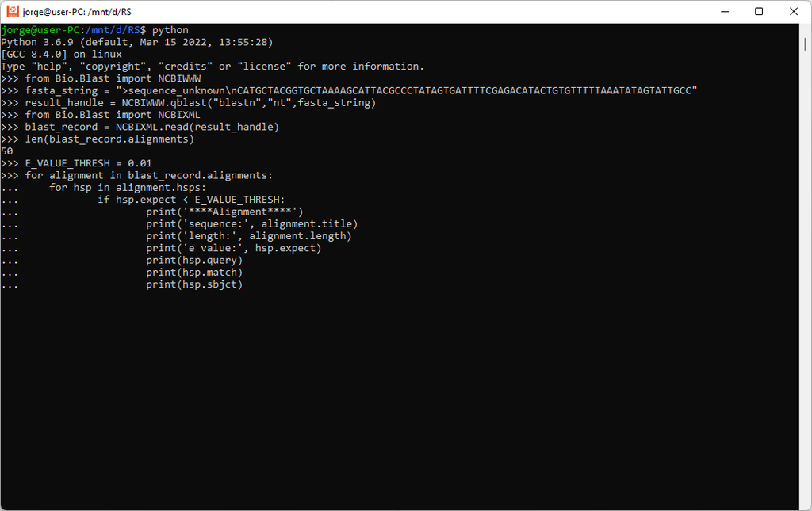

[figure not shown]

For more information on Biopython, we can consult the [cookbook](http://biopython.org/DIST/docs/tutorial/Tutorial.html) and the [FAQ](http://biopython.org/DIST/docs/tutorial/Tutorial.html#htoc5)